# Visualizing Comparisons and Compositions

# Introduction

Welcome to our tutorial on visualizing comparisons and compositions using {ggplot2} in R. Analyzing and comparing categories, as well as visually representing the composition of elements, are fundamental aspects of data visualization in R.

In this lesson, we’ll explore a variety of visualization techniques for these two applications!

We will start our journey by examining bar charts, a foundational element in data visualization. Bar charts offer exceptional versatility, allowing straightforward comparisons across diverse categories. However, when our focus shifts to understanding proportions or compositions, pie charts and donut charts come into play. These charts prove invaluable in visually representing data where the cumulative sum of all parts constitutes a whole.

This tutorial aims to equip you with the skills to effectively visualize aggregated data and make comparisons. By the end, you’ll have a solid understanding of how to use {ggplot2} functions to visualize and compare groups in your data, enhancing your ability to draw meaningful insights from your datasets. Let’s get started!

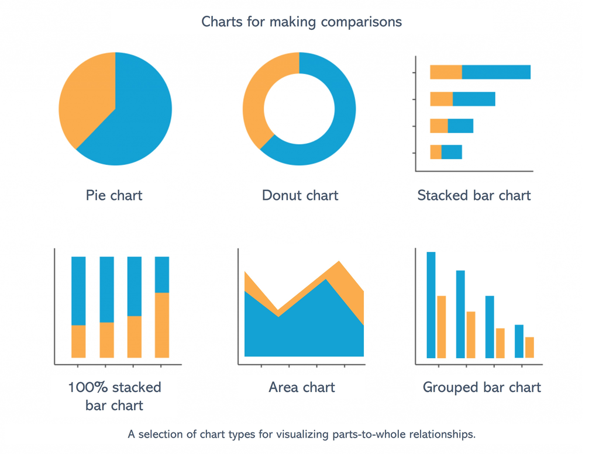

Chart types covered in this lesson.

# Learning objectives

1. Understand the difference between visualizing comparisons and visualizing compositions, and recall the appropriate chart types for these two types of analysis.
2. Create and customize bar charts using {ggplot2} for comparing categorical data, with `geom_col()`, `geom_errorbar()`, and `position` adjustments.
3. Create area plots with `geom_area()` for visualizing comparisons.
4. Understand the principles of creating effective pie and donut charts for visualizing compositions.
5. Create and customize pie and donut charts using `coord_polar()` with `geom_col()`.

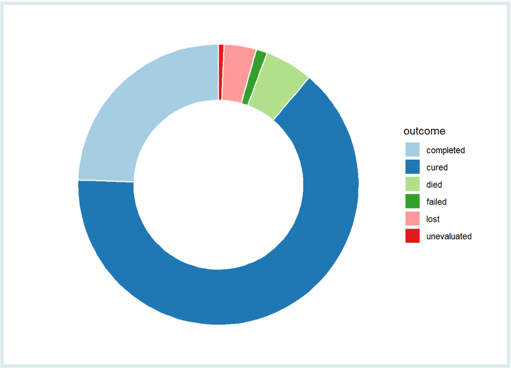

# 1 Load packages

In this lesson we will use the following packages:

- `{tidyverse}` for data wrangling and data visualization
- `{here}` for project-relative file paths

```r
pacman::p_load("tidyverse", "here")
```

# 2 Data: TB treatment outcomes in Benin

In the realm of public health, data often comes in forms that require us to compare metrics between subgroups, or understand the relative contributions to a total count.

Today we’ll be looking at sub-national tuberculosis (TB) data from Benin. The data was provided by WHO and hosted on this [DHIS2 dashboard](https://tbhistoric.org/). We will be looking at a subset of this data, with records of treatment outcomes for TB patients in hospitals, from 2015 to 2017.

Let’s import the `tb_outcomes` data subset.

```r
# Import data from CSV
tb_outcomes <- read_csv(here::here('data/benin_tb.csv'))

# Print data frame
tb_outcomes
```

| period | period_date | hospital | outcome | cases | diagnosis_type |
| --- | --- | --- | --- | --- | --- |
| 2015Q4 | 2015-10-01 | St Jean De Dieu | failed | 0 | bacteriological |
| 2015Q4 | 2015-10-01 | St Jean De Dieu | unevaluated | 0 | bacteriological |
| 2015Q4 | 2015-10-01 | St Jean De Dieu | died | 0 | bacteriological |
| 2015Q4 | 2015-10-01 | St Jean De Dieu | lost | 0 | bacteriological |
| 2015Q4 | 2015-10-01 | St Jean De Dieu | completed | 0 | bacteriological |
| 2015Q4 | 2015-10-01 | St Jean De Dieu | cured | 11 | bacteriological |
| 2015Q3 | 2015-07-01 | St Jean De Dieu | failed | 0 | bacteriological |
| 2015Q3 | 2015-07-01 | St Jean De Dieu | unevaluated | 0 | bacteriological |
| 2015Q3 | 2015-07-01 | St Jean De Dieu | died | 0 | bacteriological |
| 2015Q3 | 2015-07-01 | St Jean De Dieu | lost | 0 | bacteriological |

[output cut: 701 more lines]

The data contains records of the number of new and relapse cases started on treatment (`cases`). The case counts are disaggregated by a number of groupings: time period, health facility, treatment outcome, and diagnosis type.

# 3 Visualizing comparisons

Visualizations allow you to ask questions of your data, and the type of question you want to ask will determine the chart type. A ton of questions you might ask about your data will hinge on a comparison between values. Which region was responsible for the most cases or deaths? What year had the best treatment outcomes? These questions are answered quickly by gathering and comparing different values in your data.

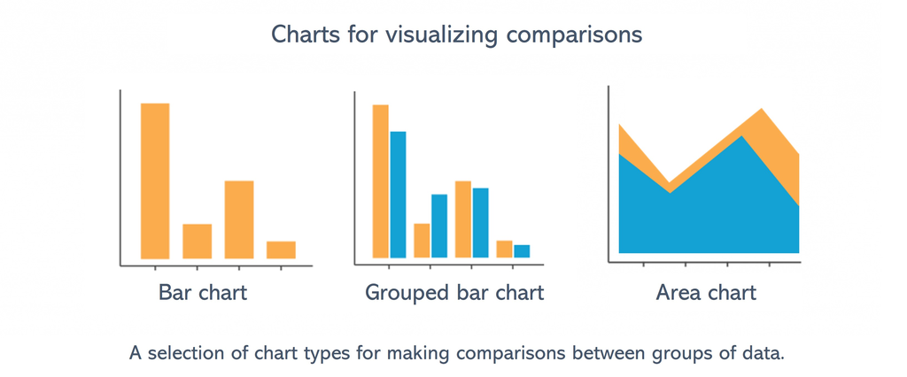

## 3.1 Bar charts

One of the most common chart types are bar charts, and for good reason! They are often the most efficient and effective way of conveying counts per group or category so that comparisons can be made between the bars.

They are especially effective when the categories are ordinal (i.e. contain an inherent order; e.g., age groups), or time based (e.g., months of the year).

But when should we consider choosing a bar/column chart? Bar charts are ideally used when dealing with data that can be **grouped into categories** and when wanting to make **comparisons** between these categories.

When using {ggplot2}, we can use the `geom_col()` function to create a bar plot of a categorical variable against a numerical variable.

Let’s exemplify this by visualizing the *Number of cases per treatment outcomes* in the `tb_outcomes` dataset:

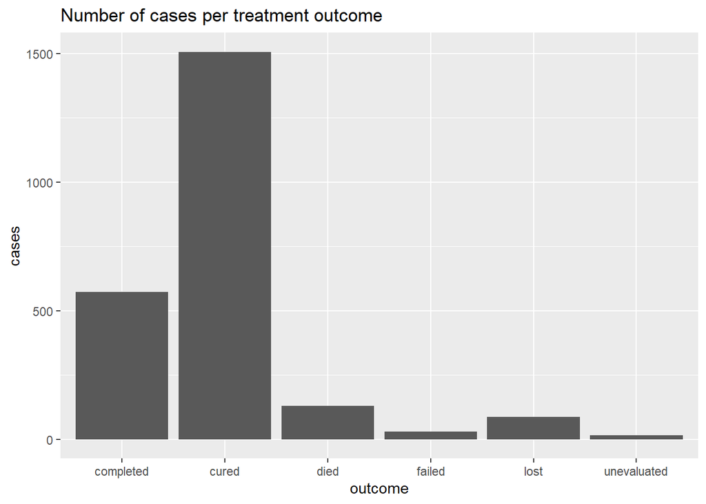

```r
# Basic bar plot example 1: Frequency of treatment outcomes
tb_outcomes %>%
  # Pass the data to ggplot as a basis for creating the visualization
  ggplot(
    # Specify that the x and y axis variables
    aes(x = outcome, y = cases)) +
  #  geom_col() creates a bar plot
  geom_col() +
  labs(title = "Number of cases per treatment outcome")
```

As we can see from the graph above, `geom_col()` has automatically tallied the total number of cases per outcomes, across all periods, hospitals, and diagnosis types.

We can also change the x-axis variable to any other categorical variable in the data as below:

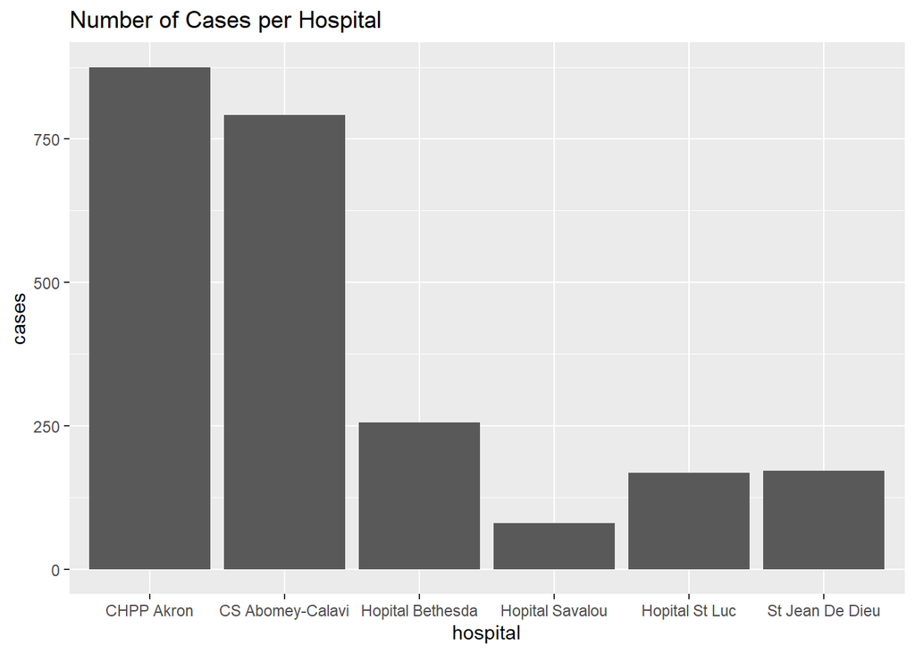

```r
# Basic bar plot example 2: Case counts per hospital
tb_outcomes %>%
  ggplot(aes(x = hospital, y = cases)) +
  geom_col() +
  labs(title = "Number of Cases per Hospital")
```

In order to properly visualize the various categories, we can generate a horizontal bar plot, by integrating the `coord_flip()` function into our previous code.

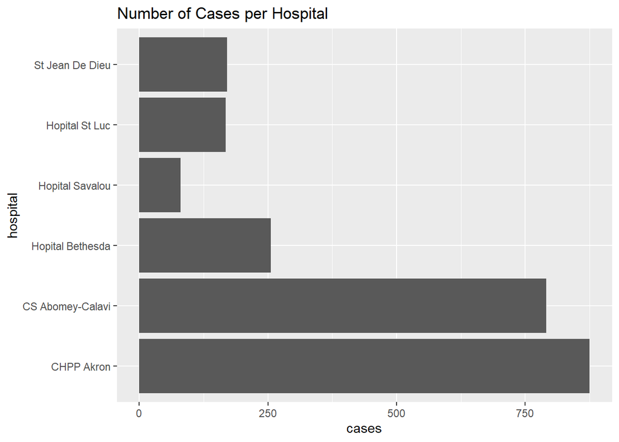

```r
# Basic bar plot example 3: Horizontal bars
tb_outcomes %>%
  ggplot(aes(x = hospital, y = cases)) +
  geom_col() +
  labs(title = "Number of Cases per Hospital") +
  coord_flip()
```

We will use `coord_*()` functions later in the lesson to create circular plots.

## 3.2 Stacked bar charts

While the previous bar charts depicted case distribution across a *single categorical variable*, we can elevate our understanding by introducing a *second categorical variable* and creating **stacked bar charts**.

This can be done in `ggplot()` by setting fill color to a categorical variable:

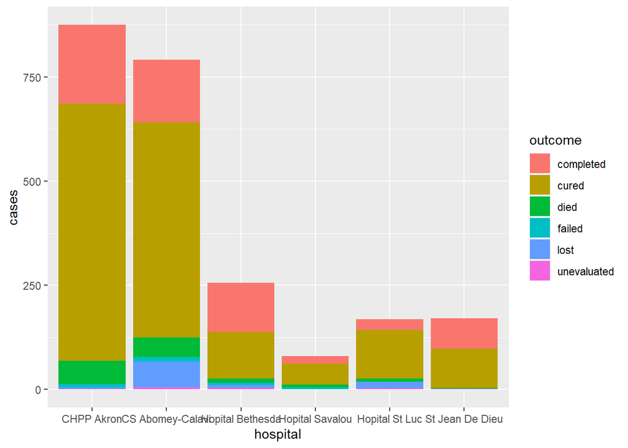

```r
# Stacked bar plot:
tb_outcomes %>%
  ggplot(
    # Fill color of bars by the 'outcome' variable
    aes(x = hospital,
        y = cases,
        fill = outcome)) +
  geom_col()
```

As seen above, stacked plots maintain our *primary categories* on the axis while visually **segregating contributions** from different subgroups by splitting the bars into smaller segments.

## 3.3 Grouped bar charts

- Grouped bar plots provide a side-by-side representation of subgroups within each main category.
- We can set the `position` argument to `"dodge"` in `geom_col()` to display bars side by side:

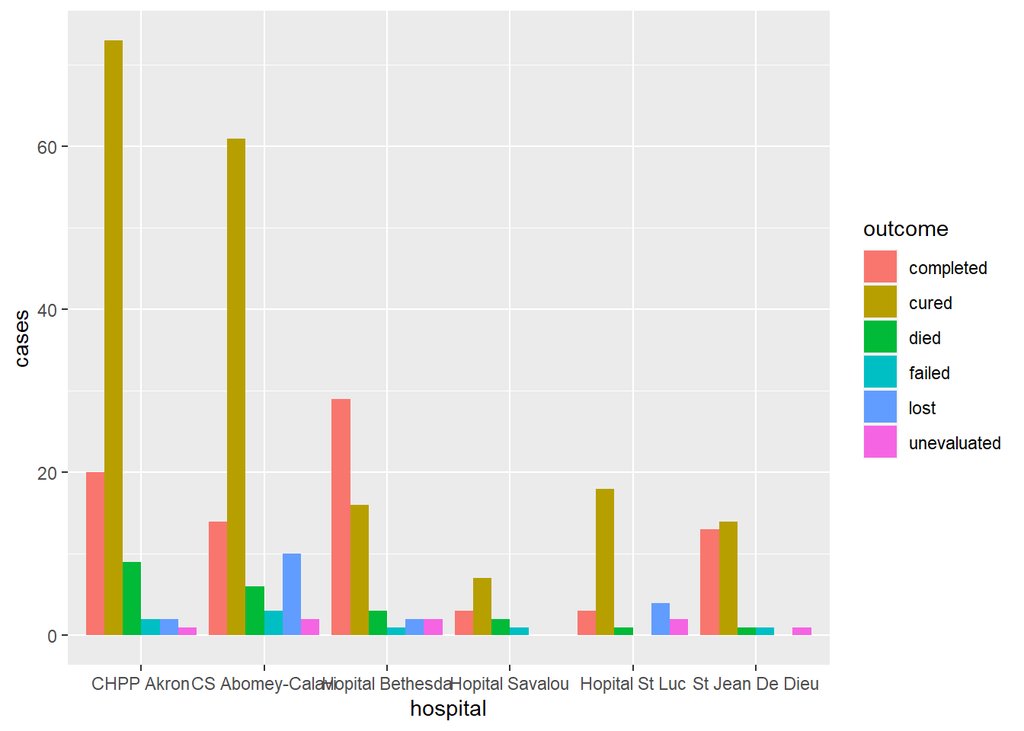

```r
# Grouped bar plot:
tb_outcomes %>%
  ggplot(
    aes(x = hospital,
        y = cases,
        fill = outcome)) +
  # Add position argument for side-by-side bars
  geom_col(position = "dodge")
```

- Grouped bar charts are not ideal when there are too many groups.
- We can try this again but with a different grouping variable that has fewer categories:

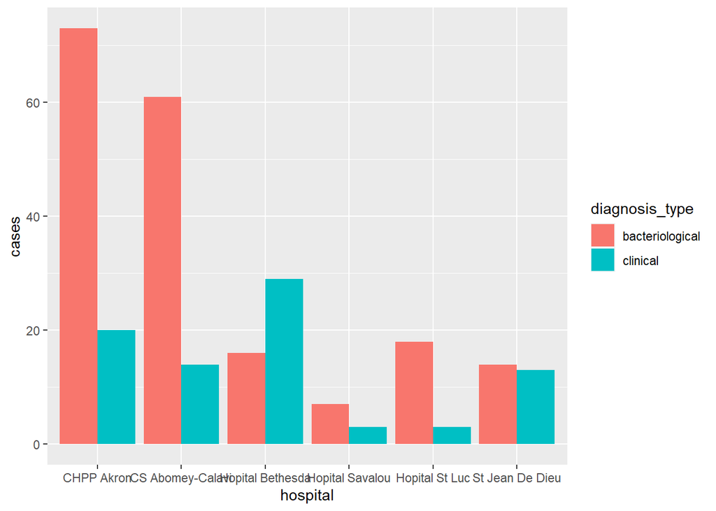

```r
# Grouped bar plot: split into 2 bars
tb_outcomes %>%
  ggplot(
    # Fill color of bars by the 'diagnosis_type'
    aes(x = hospital,
        y = cases,
        fill = diagnosis_type)) +
  geom_col(position = "dodge")
```

**Question 1: Basic bar plot**

Write the adequate code that generates a basic bar chart of the number of `cases` per quarter with `period_date` on the x axis

```r
# PQ1 answer:
tb_outcomes %>%
  ggplot(aes(------, ------)) +
  geom_col()
```

```
## Error: <text>:3:20: unexpected ','
## 2: tb_outcomes %>%
## 3:   ggplot(aes(------,
##                       ^
```

**Question 2: Stacked bar plot**

Create a stacked bar chart to display treatment outcomes over different time periods

```r
# PQ2 answer:
tb_outcomes %>%
  ggplot(
    aes(-----, ------, ------)) +
  geom_col()
```

```
## Error: <text>:4:14: unexpected ','
## 3:   ggplot(
## 4:     aes(-----,
##                 ^
```

## 3.4 Adding error bars

Visualizing data with error bars allows for a clearer understanding of the variability or uncertainty inherent in the dataset. Error bars can indicate the reliability of a mean score or an individual data point, providing context to the plotted values.

To implement error bars in {ggplot2}, we use the `geom_errorbar()` function. This requires a value for the range of your error, typically defined by the standard deviation, standard error, or confidence intervals.

Here’s an example of how to add error bars to our grouped `geom_col()` plot above.

First, let’s create the necessary summary data since we need to have some kind of error measurement. In our case we will compute the standard deviation:

```r
hosp_dx_error <- tb_outcomes %>%
  group_by(period_date, diagnosis_type) %>%
  summarise(
    total_cases = sum(cases, na.rm = T),
    error = sd(cases, na.rm = T))

hosp_dx_error
```

```
## # A tibble: 24 × 4
## # Groups:   period_date [12]
##    period_date diagnosis_type  total_cases error
##    <date>      <chr>                 <dbl> <dbl>
##  1 2015-01-01  bacteriological         143 11.9
##  2 2015-01-01  clinical                 47  4.40
##  3 2015-04-01  bacteriological         163 13.0
##  4 2015-04-01  clinical                 35  3.84
##  5 2015-07-01  bacteriological         146 11.2
##  6 2015-07-01  clinical                 34  3.33
##  7 2015-10-01  bacteriological         152 10.4
##  8 2015-10-01  clinical                 43  3.55
##  9 2016-01-01  bacteriological         201 15.7
## 10 2016-01-01  clinical                 71  7.01
## # ℹ 14 more rows
```

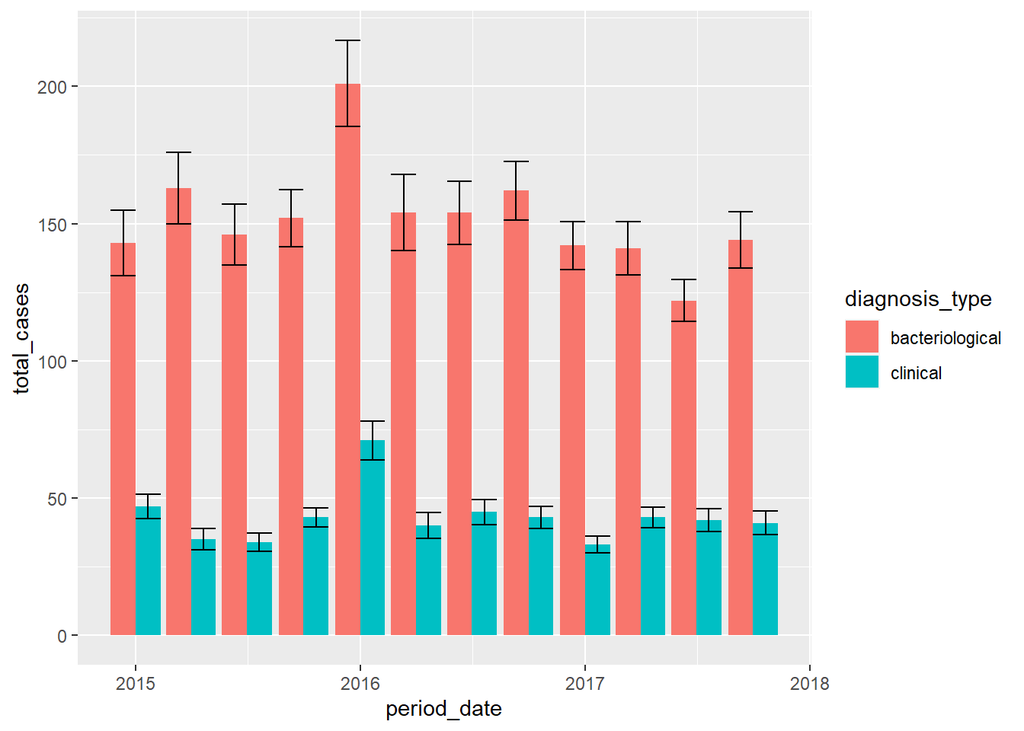

```r
# Recreate grouped bar chart and add error bars
hosp_dx_error %>%
  ggplot(
    aes(x = period_date,
        y = total_cases,
        fill = diagnosis_type)) +
  geom_col(position = "dodge") +  # Dodge the bars
  #  geom_errorbar() adds error bars
  geom_errorbar(
    # Specify upper and lower limits of the error bars
    aes(ymin = total_cases - error, ymax = total_cases + error),
    position = "dodge"  # Dodge the error bars to align them with side-by-side bars
  )
```

## 3.5 Area charts

In this section, we’ll be exploring area plots with `geom_area()`. These plots are especially advantageous for visualizing a range of data values or the progression of data across time, making them ideal for use cases like tracking the number of new treatment cases per quarter.

Let’s start by visualizing this distribution with a stacked bar chart:

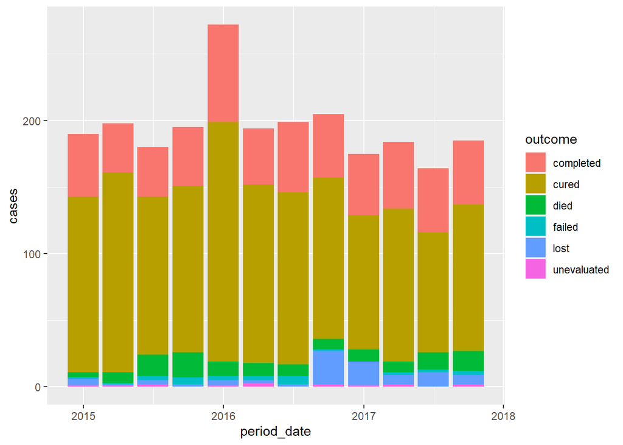

```r
tb_outcomes %>%
  ggplot(
    aes(x = period_date,
        y = cases,
        fill = outcome)) +
  geom_col()
```

- Unlike `geom_col()`, `geom_area()` will not automatically compute the sums for each category.
- We need to group summarize our data so we have a data frame with the sum of cases for every treatment outcome per quarter:

```r
# Create summary data frame
outcome_by_period <- tb_outcomes %>%
  group_by(period_date, outcome) %>%
  summarise(
    total_cases = sum(cases, na.rm = T))

outcome_by_period
```

```
## # A tibble: 72 × 3
## # Groups:   period_date [12]
##    period_date outcome     total_cases
##    <date>      <chr>             <dbl>
##  1 2015-01-01  completed            47
##  2 2015-01-01  cured               132
##  3 2015-01-01  died                  4
##  4 2015-01-01  failed                1
##  5 2015-01-01  lost                  5
##  6 2015-01-01  unevaluated           1
##  7 2015-04-01  completed            37
##  8 2015-04-01  cured               150
##  9 2015-04-01  died                  8
## 10 2015-04-01  failed                1
## # ℹ 62 more rows
```

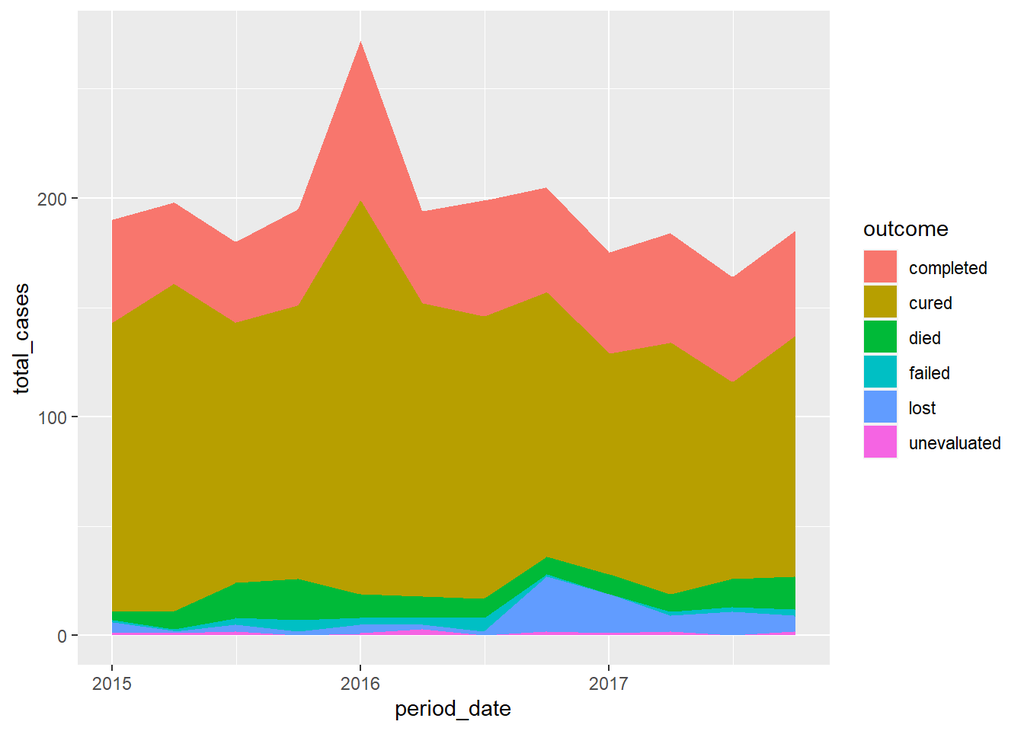

```r
# Area plot of treated cases over time
outcome_by_period %>%
ggplot(
  aes(
    x = period_date,    # Map 'period' to the x-axis
    y = total_cases,     # Map 'value' to the y-axis
    fill = outcome    # Map 'variable_name' to the fill aesthetic
  )) +
  #  geom_area() creates an area plot
  geom_area()
```

Suppose we now want to ask what outcome contributes most to each section, or track the proportion of cured cases in each period over time. These questions also involve comparisons, but they are subtly different. Instead of comparing total values, we want to compare the relative contribution of those values to a bigger whole as proportions or percentages. In other words, we are interested in looking at the composition, or part-to-whole relationships. In the next section we will learn how to visualize these relationships.

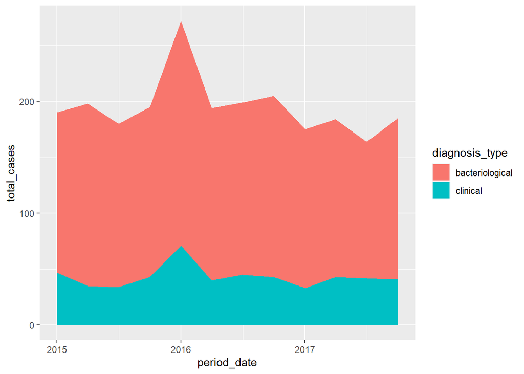

```r
# PQ 3 answer
tb_outcomes %>%
  group_by(period_date, diagnosis_type) %>%
  summarise(
    total_cases = sum(cases, na.rm = T)) %>%
ggplot(
  aes(
    x = period_date,
    y = total_cases,
    fill = diagnosis_type)) +
  geom_area()
```